# Political Process and Resource Mobilization theories

## Resource Mobilization

### RMT: Basic Assumptions

Key citation: McCarthy, J. D., & Zald, M. N. (1977). Resource mobilization and social movements: A partial theory. American journal of sociology, 82(6), 1212-1241.

1. “Strain” alone is not sufficient because protest requires resources.
2. Powerless groups lack access to these resources, so external actors have to supply them.
3. Mobilization resources are finite, so activists form organizations to compete for them.

> “*…there is always enough discontent in any society to supply the grass-roots support for a movement if the movement is effectively organized and has at its disposal the power and resources of some established elite group*” - Ralph Turner and Lewis Killian (1972)

### RMT: Key Actors

**Social Movement**

A set of opinions or preferences that favor changing society.

**Social Movement Organizations (SMO)**

Formal organizations aligned with an SM

**Social Movement Industries (SMI)**

The set of SMOs organized around an issue.

### RMT: Mobilized groups

Movements need people, but **who they mobilize** is drives organizational behavior.

- level of involvement
- size/access to resources
- relationship to the goals of the movement

### Resource Mobilization and Civil Rights

- Resource Mobilization Theorists offer a compelling explanation for the Civil Rights era and the explosion of movement activity after WWII
  - Economic changes: middle class with free time and discretionary income
  - Changes among elites: institutional support for activists from unions, political parties, and churches
  - Demographic shifts: growing college-educated workforce and lots of young people

### Resource Mobilization: Civil Rights SMOs

Selected SMOs in the Civil Rights Movement

| Organization | Year Created |
| --- | --- |
| National Association for the Advancement of Colored People (NAACP) | 1909 |
| National Urban League (NUL) | 1910 |
| NAACP Legal Defense Fund (LDF) | 1940 |
| Congress of Racial Equality (CORE) | 1942 |
| Southern Regional Council (SRC) | 1944 |
| Southern Christian Leadership Conference (SCLC) | 1957 |
| Student Nonviolent Coordinating Committee (SNCC) | 1960 |

### External Support for Civil Rights SMOs

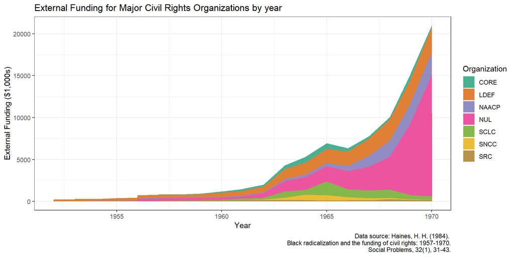

# Critiques

### Critiques: do powerless groups lack leverage?

- Some tools *are* available to resource-poor groups without external support:
  - Labor strikes
  - Sit-ins, boycotts and other forms of disruption
  - Riots and the threat of violence

### Critiques: the role of grievance

- Grievance is alone is not enough, but neither are grievances + resources.
- Many grievances are de-politicized, viewed as just or the result of personal failures, or viewed as insurmountable through collective action.

### Critiques: the role of elites and organizations

- Do professional groups do most of the heavy lifting for movements?
- Is elite/institutional support an unalloyed good? What are the downsides?
- What are the strategic goals of elites/institutional supporters?

> *It is not possible to compel concessions from elites that can be used as resources to sustain oppositional organizations over time… Organizations endure, in short, by abandoning their oppositional politics.*

> Piven, Frances Fox, and Richard Cloward. *Poor people’s movements: Why they succeed, how they fail*. Vintage, 1978.

### Critiques: Elite support and moderation

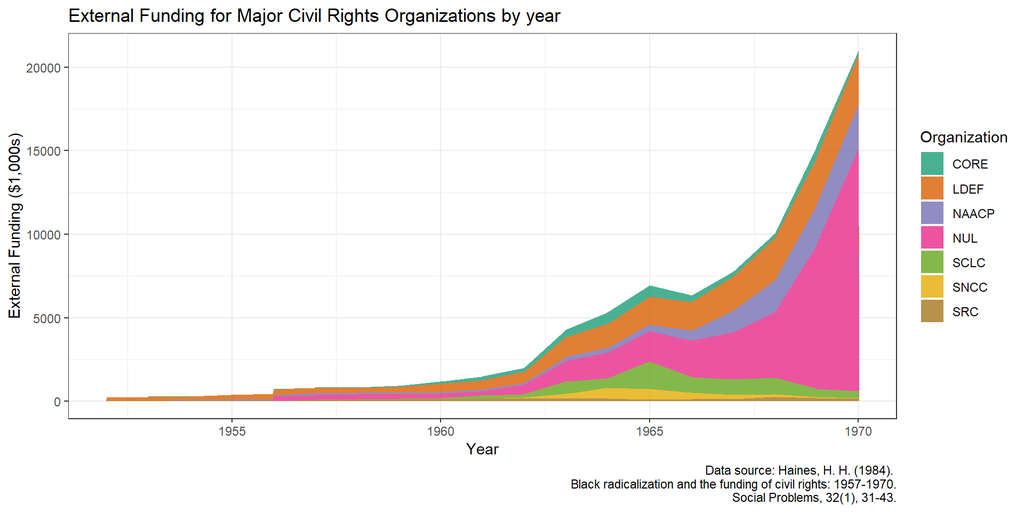

## Political Process Model

3 key factors

[figure not shown]

### Civil Rights: Socioeconomic processes

- Post-Reconstruction period (1877 - 1920s): low point for civil rights in the U.S.
- Increasing black electoral power following WWI (but continued segregation in the south)
- Post WWII: emerging black middle class, weakening of the north-south elite party alliance, sympathetic Supreme Court

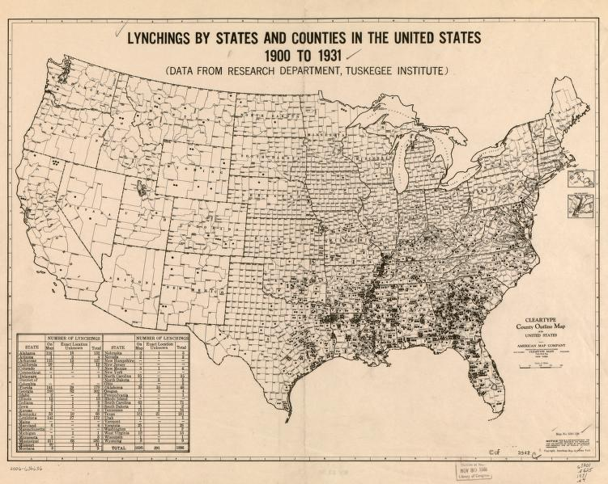

### Civil Rights: Political Opportunity Structures in 1960s

- Partisan competition: black voters became a key swing constituency
- Increased public attention/sympathy for civil rights causes
- Sense among elites that segregation undermines U.S. global reputation; concerns about the effect of (esp. televised) violence on public opinion

### Civil Rights: Expansion of protest

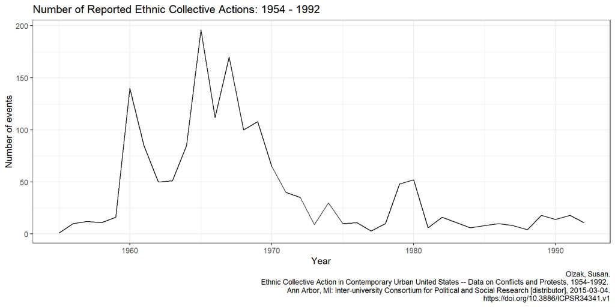

### Civil Rights: Timing and role of External Support

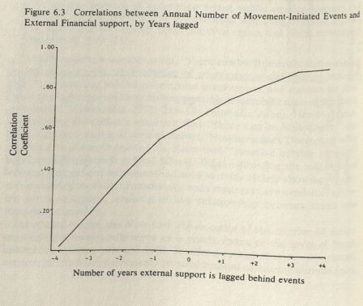

### Civil Rights: Indigenous Organizational Strength

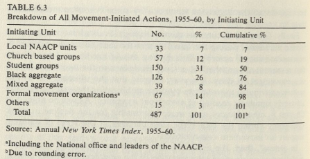

### Civil Rights: Indigenous Organizational Strength

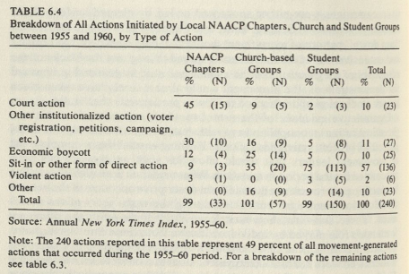

### Civil Rights: Communication Networks

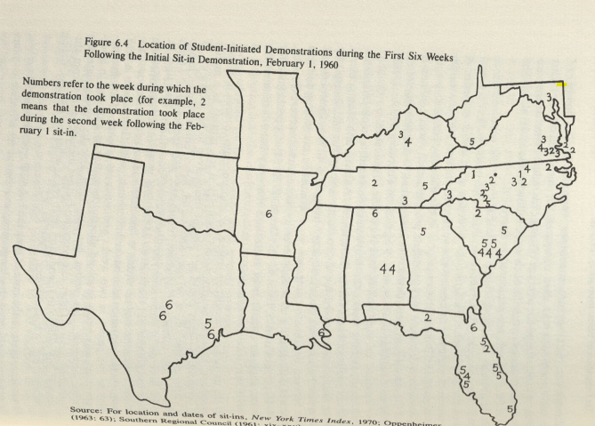

### Civil Rights: tactics and the pace of protest

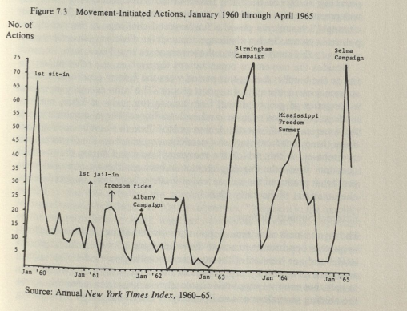

### Civil Rights: Cognitive Liberation

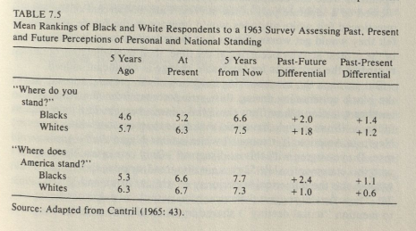

### Civil Rights: Supremacists and Government action

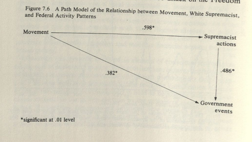

### Civil Rights: elites and demobilization

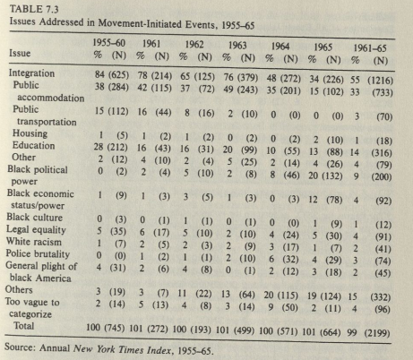

### Civil Rights: elites and demobilization

[figure not shown]